# Part II - (Data Exploraation of Bike Sales Dataset)

## by (Opeyemi Ogundile)

## Investigation Overview

> In this project I wanted to see the variables that brought it more sales for the Bike stores. Also to check if there was an impact of Cost on Revenue. I also considered profit made by different age groups. The main variables considered were Ageof customer, Country of Customer, State of Customer, Gender of Customers, Cost of products, Products, Product Category, Revenue, and Profit.

## (Distribution of Profit made on Bike Sales)

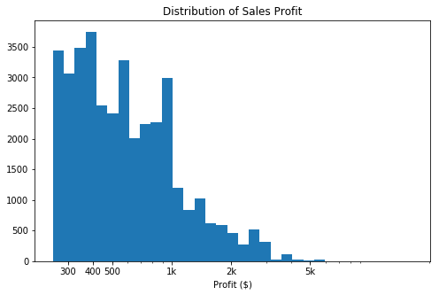

## (Distribution of Customer Age)

The distribution of Customer age is skewed to the Right.

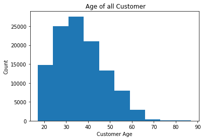

## (The Normal distrbution of Revenue Versus Log transform)

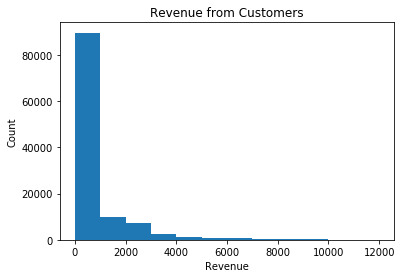

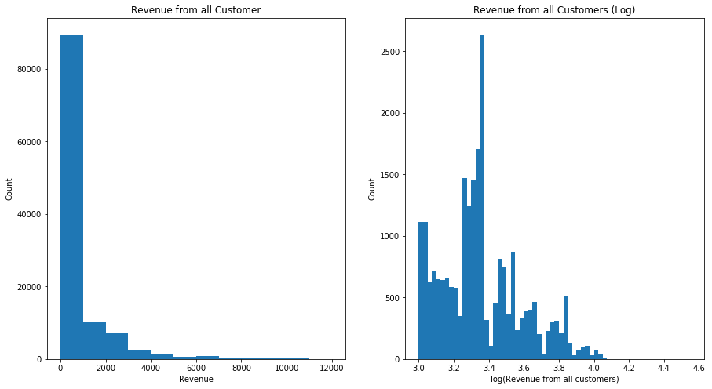

### Sales in Year

Plotting the Year agisnt frequency. It was noticed that two years 2016 and 2014) had same number of sales.

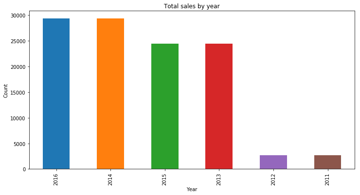

### Sales by Country

From the Bar chart plot, United States Customers brought in more sales follow by Australia.

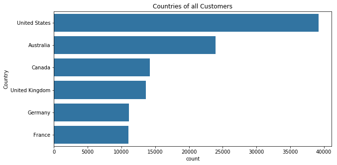

### Revenue By Customer Gender

Here we plotted a violin plot that revealed which Gender brought in more sales. It was obvious that the Male customer did better than Female. However, an interesting fact will be revealed later.

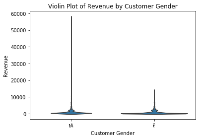

### Sales Across Age Group, Gender, Product Category

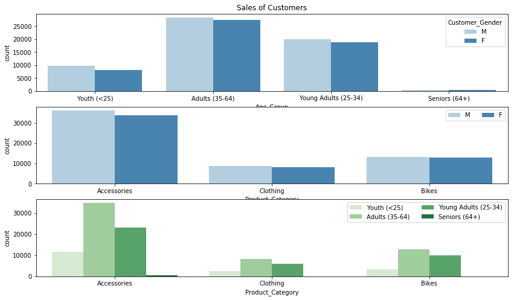

### Relationship Between Revenue and Profit

Plotting the Corellation between Profit and Revenue showed that there is a strong correlation between the two variables. Meaning that the higher the revenue the higher the profit made.

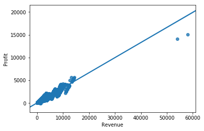

```
Correlation coefficient between Revenue and Profit: 0.956571664074
```

### Relationship Between Cost and Revenue

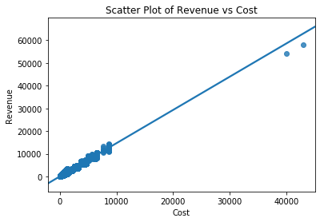

The above corelation result indicte clear that there is positive corelation between Cost and Revenue

[figure not shown]

### Relationship Between Quantitative Variables

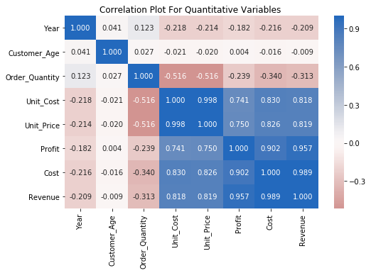

### Time series of Profit by Year

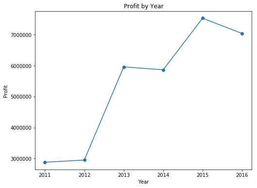

### Profit across Age group and Customer gender

From the one of the previous analysis above we concluded that Male customers brings more profit. However, from the current investigation we can see that Female customers in Adult (35-64) and young Adults (25-34) categories bring in more profit.

```
Text(0.5,1,'Sales Profit across Age_Group and Customer_Gender')
```

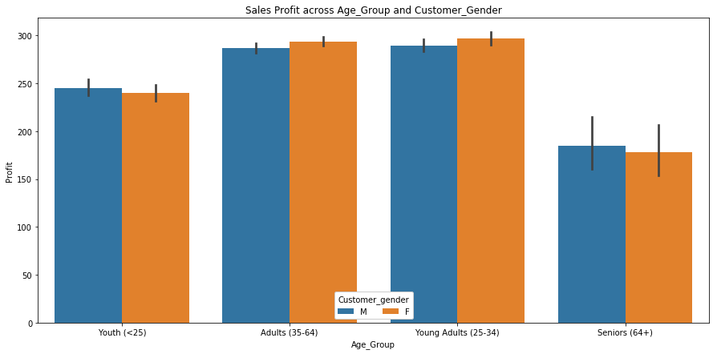